# Estudio sobre infectados de coronavirus

## Planteamiento y modelado del problema

## Introducción

En estos días está como noticia estrella la pandemía por **coronavirus** que estamos sufriendo prácticamente todos los humanos que habitan nuestro planeta.

Una de las cuestiones más planteadas es cómo irán evolucionando los infectados, es decir, si a partir de los datos que se tienen, podemos predecir si habrá un rebrote o no.

En esta presentación vamos a modelar los datos de los infectados, fallecidos y recuperados por una **serie temporal** e intentar sacar conclusiones de dicho estudio.

Vamos a realizar todo nuestro estudio usando el paquete estadístico `R`.

## Tabla de datos

Para realizar el estudio anterior, usaremos la tabla de datos `covid19`.

Vamos a cargarla:

```r
covid19=read.csv("covid_19_clean_complete.csv")
covid19$Date=as.Date(as.character(covid19$Date),"%m/%d/%Y")
```

## Tabla de datos

Hagamos un pequeño resumen de las variables de dicha tabla de datos:

```r
str(covid19)
```

```
## 'data.frame':    21484 obs. of  8 variables:
##  $ Province.State: Factor w/ 81 levels "","Alberta","Anguilla",..: 1 1 1 1 1 1 1 1 6 49 ...
##  $ Country.Region: Factor w/ 185 levels "Afghanistan",..: 1 2 3 4 5 6 7 8 9 9 ...
##  $ Lat           : num  33 41.2 28 42.5 -11.2 ...
##  $ Long          : num  65 20.17 1.66 1.52 17.87 ...
##  $ Date          : Date, format: "0020-01-22" "0020-01-22" ...
##  $ Confirmed     : int  0 0 0 0 0 0 0 0 0 0 ...
##  $ Deaths        : int  0 0 0 0 0 0 0 0 0 0 ...
##  $ Recovered     : int  0 0 0 0 0 0 0 0 0 0 ...
```

## Tabla de datos

Como vemos, es una tabla de datos con 8 variables:

- `Province.State`: nos indica la provincia o el estado del país en cuestión.
- `Country.Region`: nos dice el país donde están los datos.
- `Lat`: nos da la latitud del pais.
- `Long`: nos da la longitud del pais.
- `Date`: nos dice la fecha en la que han sido tomados los datos.
- `Confirmed`: nos da el número de infectados en una determinada región de un país determinado en una fecha determinada.
- `Death`: lo mismo que la variable anterior pero nos da el número de víctimas.
- `Recovered`: lo mismo que la variable anterior pero nos da el número de recuperados.

## Estudio para España

## Tabla de datos para España

Para ello, en primer lugar, creamos la tabla con los datos del coronavirus sólo para España:

```r
covid19.España = covid19[covid19$Country.Region=="Spain",]
```

A continuación calculamos los infectados y los recuperados por días:

```r
infectados.por.dia = aggregate(covid19.España$Confirmed ~ covid19.España$Date,FUN=sum)
fallecidos.por.dia = aggregate(covid19.España$Deaths ~ covid19.España$Date,FUN=sum)
recuperados.por.dia = aggregate(covid19.España$Recovered ~ covid19.España$Date,FUN=sum)
```

## Tabla de datos para España

Por último creamos la tabla `tabla.España` con toda la información:

```r
tabla.España = data.frame(unique(covid19.España$Date),infectados.por.dia[,2],
                          fallecidos.por.dia[,2],recuperados.por.dia[,2])
names(tabla.España) = c("Fecha", "Infectados","Fallecidos", "Recuperados")
```

## Tabla de datos para España

La información de los 10 primeros días será donde vemos que aún no hay ningún infectado ni recuperado:

```r
head(tabla.España,10)
```

```
##         Fecha Infectados Fallecidos Recuperados
## 1  0020-01-22          0          0           0
## 2  0020-01-23          0          0           0
## 3  0020-01-24          0          0           0
## 4  0020-01-25          0          0           0
## 5  0020-01-26          0          0           0
## 6  0020-01-27          0          0           0
## 7  0020-01-28          0          0           0
## 8  0020-01-29          0          0           0
## 9  0020-01-30          0          0           0
## 10 0020-01-31          0          0           0
```

## Estudio para los infectados

## Cálculo de la serie temporal de infectados

Vamos a de modelar el número de infectados como una serie temporal:

```r
infectados = ts(tabla.España$Infectados,frequency = 7,start=c(1,3))
infectados
```

```
## Time Series:
## Start = c(1, 3)
## End = c(12, 7)
## Frequency = 7
##  [1]      0      0      0      0      0      0      0      0      0      0
## [11]      1      1      1      1      1      1      1      1      2      2
## [21]      2      2      2      2      2      2      2      2      2      2
## [31]      2      2      2      2      6     13     15     32     45     84
## [41]    120    165    222    259    400    500    673   1073   1695   2277
## [51]   2277   5232   6391   7798   9942  11748  13910  17963  20410  25374
## [61]  28768  35136  39885  49515  57786  65719  73235  80110  87956  95923
## [71] 104118 112065 119199 126168 131646 136675 141942 148220 153222 158273
## [81] 163027 166831
```

## Cálculo de la serie temporal de infectados

El gráfico de la serie temporal de los infectados en España se visualiza con la función `plot.ts`:

```r
plot.ts(infectados)
```

## Cálculo de la serie temporal de infectados

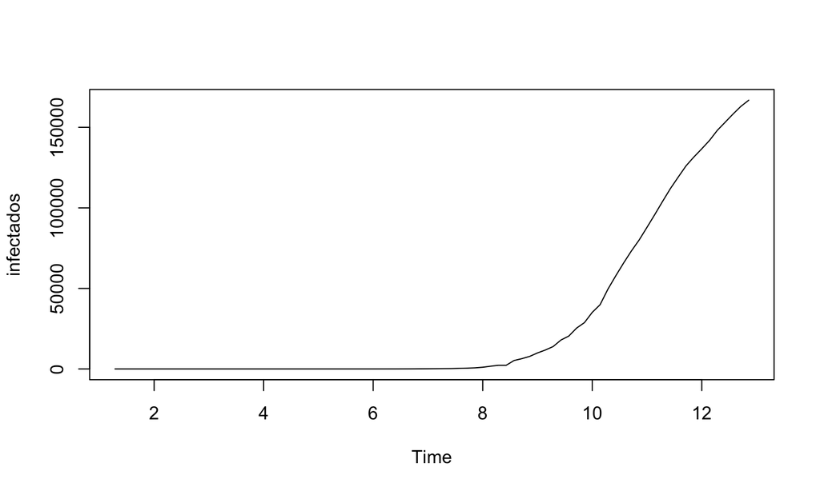

## Cálculo de las componentes de la serie

Nuestra serie temporal es estacional con variación semanal.

Calculemos a continuación sus componentes suponiendo que el modelo es **aditivo**:

```r
components = decompose(infectados,type="additive")
```

## Cálculo de las componentes de la serie

La componente adicional de la serie de afectados es la siguiente:

```r
components$seasonal
```

```
## Time Series:
## Start = c(1, 3)
## End = c(12, 7)
## Frequency = 7
##  [1]    7.738219  142.192764  191.427829  226.114842 -120.002041
##  [6] -125.989054 -321.482560    7.738219  142.192764  191.427829
## [11]  226.114842 -120.002041 -125.989054 -321.482560    7.738219
## [16]  142.192764  191.427829  226.114842 -120.002041 -125.989054
## [21] -321.482560    7.738219  142.192764  191.427829  226.114842
## [26] -120.002041 -125.989054 -321.482560    7.738219  142.192764
## [31]  191.427829  226.114842 -120.002041 -125.989054 -321.482560
## [36]    7.738219  142.192764  191.427829  226.114842 -120.002041
## [41] -125.989054 -321.482560    7.738219  142.192764  191.427829
## [46]  226.114842 -120.002041 -125.989054 -321.482560    7.738219
## [51]  142.192764  191.427829  226.114842 -120.002041 -125.989054
## [56] -321.482560    7.738219  142.192764  191.427829  226.114842
## [61] -120.002041 -125.989054 -321.482560    7.738219  142.192764
## [66]  191.427829  226.114842 -120.002041 -125.989054 -321.482560
## [71]    7.738219  142.192764  191.427829  226.114842 -120.002041
## [76] -125.989054 -321.482560    7.738219  142.192764  191.427829
## [81]  226.114842 -120.002041
```

## Cálculo de las componentes de la serie

El gráfico de las tres componentes (estacional, tendencia y aleatorio) junto con la serie original de los infectados es el siguiente:

```r
plot(components)
```

## Cálculo de las componentes de la serie

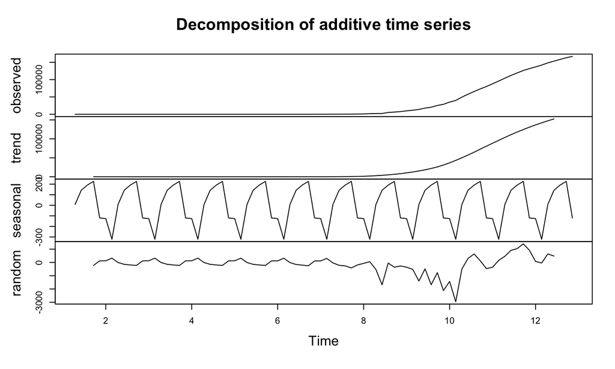

## Ajuste de la serie temporal

Para ajustar la serie temporal de los infectados, tenemos que eliminar la componente estacional:

```r
infectados.ajustados = infectados-components$seasonal
plot(infectados.ajustados)
```

## Ajuste de la serie temporal

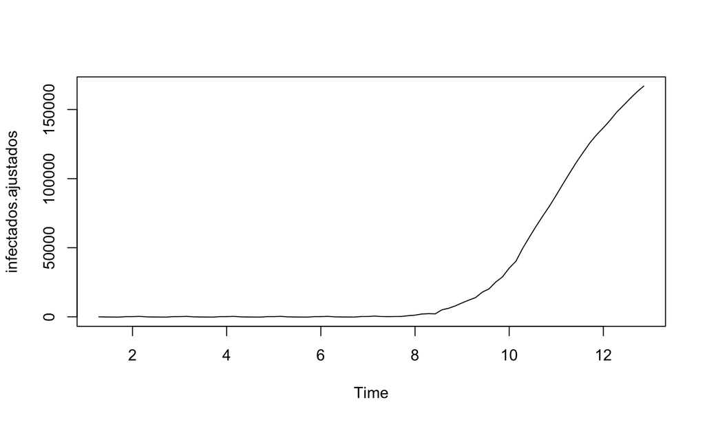

## Ajuste de la serie temporal

En la serie ajustada se ve una tendencia al crecimiento donde hemos eliminado la componente estacional por días de la semana.

Para hacer **predicciones**, hemos de usar la **serie ajustada** ya los **modelos de predicción** suponen que la serie temporal no tiene **componente estacional.**

## Predicciones usando el suavizado exponencial

Para realizar predicciones de nuestra serie temporal, podemos usar el suavizado de [**Holt-Winters**](https://en.wikipedia.org/wiki/Exponential_smoothing):

```r
(predicción.infectados=HoltWinters(infectados.ajustados,gamma=FALSE))
```

## Predicciones usando el suavizado exponencial

```
## Holt-Winters exponential smoothing with trend and without seasonal component.
##
## Call:
## HoltWinters(x = infectados.ajustados, gamma = FALSE)
##
## Smoothing parameters:
##  alpha: 0.7519468
##  beta : 1
##  gamma: FALSE
##
## Coefficients:
##         [,1]
## a 167105.744
## b   4225.935
```

## Predicciones usando el suavizado exponencial

Hemos usado un **doble suavizado exponencial** ya que el **suavizado exponencial simple** no funciona bien cuando hay una **tendencia** en la serie temporal como es nuestro caso.

El valor de \(\alpha\) es alto, lo que nos dice que las predicciones usan el nivel actual de la serie de infectados con un peso elevado, es decir, para predecir el valor de un día en particular, usa el valor de los infectados del día actual con un peso de \(0.7519468\).

## Predicciones usando el suavizado exponencial

El error cometido en las predicciones, es decir, la suma de los cuadrados de las diferencias entre los valores de la serie original ajustada y la serie ajustada, es:

```r
predicción.infectados$SSE
```

```
## [1] 46347718
```

```r
sqrt(predicción.infectados$SSE)
```

```
## [1] 6807.916
```

El gráfico de la serie original ajustada y la predicha con el suavizado doble de Holt-Winters es el siguiente:

```r
plot(predicción.infectados)
```

## Predicciones usando el suavizado exponencial

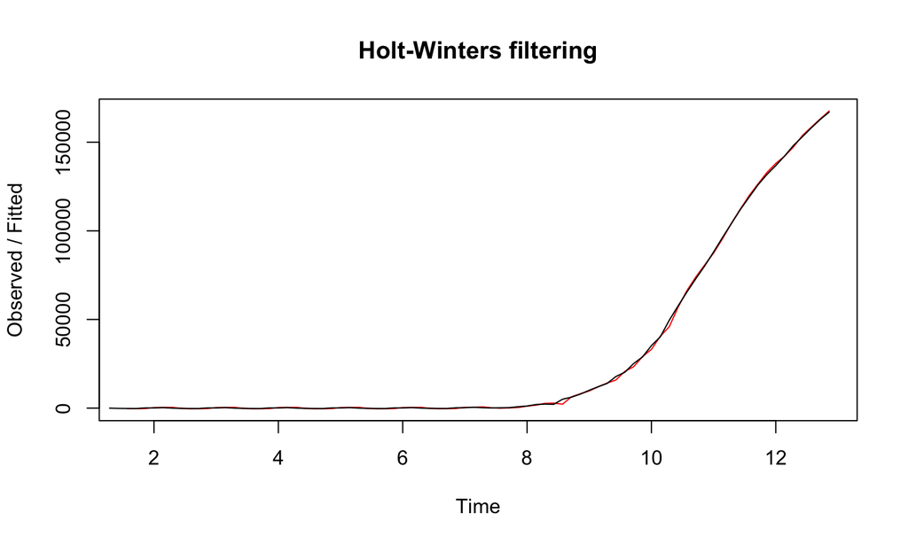

## Predicciones usando el suavizado exponencial

Para hacer predicciones más allá del último día de nuestra tabla de datos hemos de usar la función `forecast.HoltWinters` del paquete `forecast` donde el parámetro `h` indica hasta dónde queremos realizar la predicción:

```r
library(forecast)
(predicción.infectados.semana = forecast:::forecast.HoltWinters(predicción.infectados,
                                                                h=7))
```

```
##          Point Forecast    Lo 80    Hi 80    Lo 95    Hi 95
## 13.00000       171331.7 170354.5 172308.8 169837.3 172826.1
## 13.14286       175557.6 173792.9 177322.4 172858.7 178256.5
## 13.28571       179783.5 176959.9 182607.2 175465.1 184102.0
## 13.42857       184009.5 179933.8 188085.2 177776.3 190242.7
## 13.57143       188235.4 182748.3 193722.5 179843.7 196627.2
## 13.71429       192461.4 185422.6 199500.1 181696.6 203226.1
## 13.85714       196687.3 187969.7 205404.9 183354.8 210019.7
```

## Predicciones usando el suavizado exponencial

Observamos que tenemos una tabla de datos con 6 columna.

- La primera nos indica los días en que hacemos la predicción en las unidades de una semana ya que es nuestra unidad de tiempo.
- La segunda es la predicción.
- La tercera y la cuarta son los extremos del intervalo de confianza del valor predicho al 80%.
- La quinta y la sexta son los extremos del intervalo de confianza del valor predicho al 95%.

## Predicciones usando el suavizado exponencial

El gráfico de los valores predichos es el siguiente:

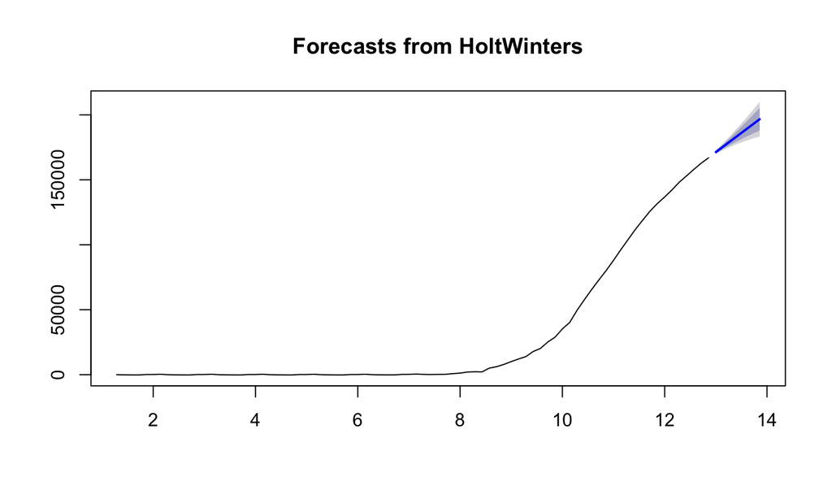

```r
forecast:::plot.forecast(predicción.infectados.semana)
```

## Comprobación del modelo

Vamos a verificar si el modelo que hemos usado es correcto para nuestra serie temporal.

En primer lugar, vamos a usar el test de [**Ljung-Box**](https://es.wikipedia.org/wiki/Prueba_de_Ljung-Box) para ver si las autocorrelaciones los errores de la predicción de nuestra serie son diferentes de cero o no. Para que el modelo sea válido, deben ser cero.

En primer lugar veamos si hay autocorrelaciones en los errores realizando un gráfico de correlograma:

```r
acf(predicción.infectados.semana$residuals[3:75], lag.max=7)
```

## Comprobación del modelo

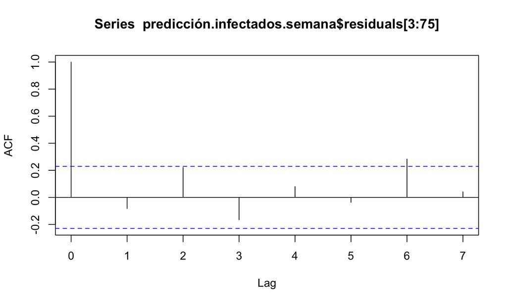

## Comprobación del modelo

Hemos especificado un “lag” máximo de 7 días. Parece que las autocorrelaciones de los errores para 6 días se pueden considerar diferentes de cero. Hagamos el test de Ljung-Box:

```r
Box.test(predicción.infectados.semana$residuals,lag=7,type="Ljung-Box")
```

```
##
##  Box-Ljung test
##
## data:  predicción.infectados.semana$residuals
## X-squared = 13.52, df = 7, p-value = 0.0604
```

Obtenemos un p-valor en la zona de penumbra, no podemos asegurar que las autocorrelaciones de las autocorrelaciones sean cero.

## Comprobación del modelo

Por último, comprobemos la normalidad de los residuos con el test de **Shapiro-Wilks**:

```r
shapiro.test(predicción.infectados.semana$residuals)
```

```
##
##  Shapiro-Wilk normality test
##
## data:  predicción.infectados.semana$residuals
## W = 0.78704, p-value = 2.089e-09
```

Vemos que el modelo no sería adecuado ya que el test anterior nos dice que los residuos no serían normales.

## Estudio para los fallecidos

## Serie temporal de los fallecidos

Hagamos lo mismo para la serie temporal de los fallecidos:

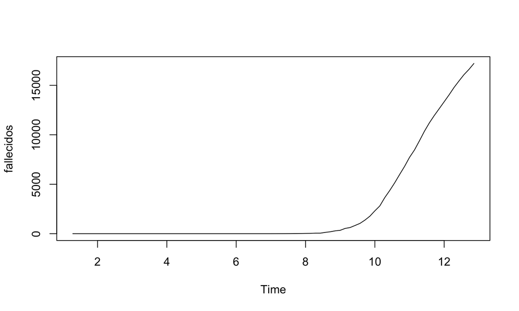

```r
fallecidos = ts(tabla.España$Fallecidos,frequency = 7,start=c(1,3))
plot.ts(fallecidos)
```

## Componentes

```r
components = decompose(fallecidos,type="additive")
components$seasonal
```

```
## Time Series:
## Start = c(1, 3)
## End = c(12, 7)
## Frequency = 7
##  [1]   4.892764  12.581076   4.539518   4.295362  -4.808534  -3.964378
##  [7] -17.535807   4.892764  12.581076   4.539518   4.295362  -4.808534
## [13]  -3.964378 -17.535807   4.892764  12.581076   4.539518   4.295362
## [19]  -4.808534  -3.964378 -17.535807   4.892764  12.581076   4.539518
## [25]   4.295362  -4.808534  -3.964378 -17.535807   4.892764  12.581076
## [31]   4.539518   4.295362  -4.808534  -3.964378 -17.535807   4.892764
## [37]  12.581076   4.539518   4.295362  -4.808534  -3.964378 -17.535807
## [43]   4.892764  12.581076   4.539518   4.295362  -4.808534  -3.964378
## [49] -17.535807   4.892764  12.581076   4.539518   4.295362  -4.808534
## [55]  -3.964378 -17.535807   4.892764  12.581076   4.539518   4.295362
## [61]  -4.808534  -3.964378 -17.535807   4.892764  12.581076   4.539518
## [67]   4.295362  -4.808534  -3.964378 -17.535807   4.892764  12.581076
## [73]   4.539518   4.295362  -4.808534  -3.964378 -17.535807   4.892764
## [79]  12.581076   4.539518   4.295362  -4.808534
```

## Componentes

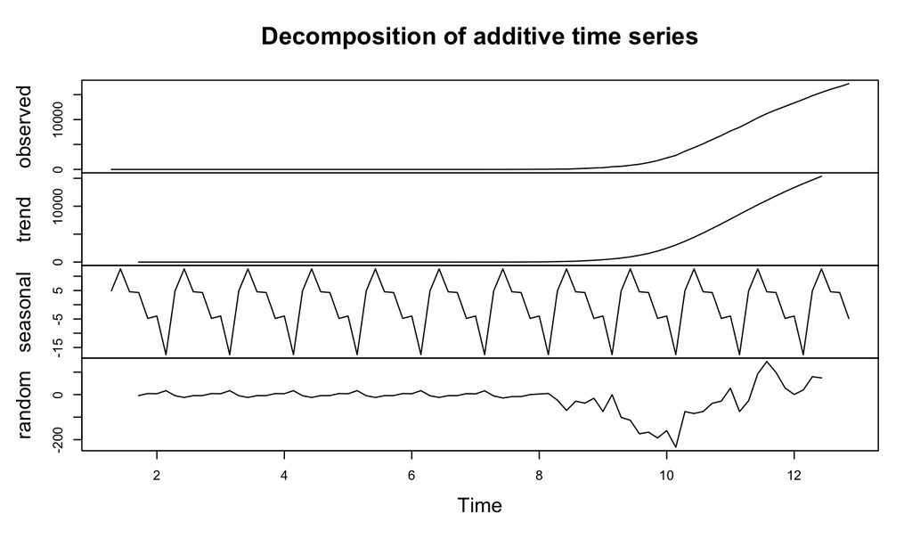

```r
plot(components)
```

## Ajuste de la serie temporal

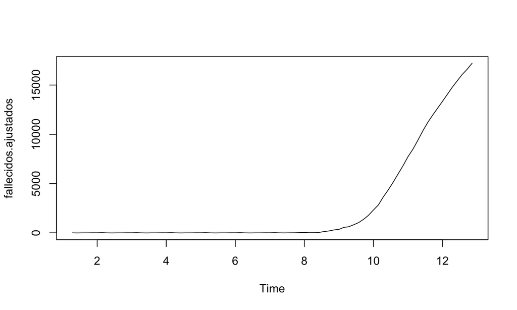

```r
fallecidos.ajustados = fallecidos-components$seasonal
plot(fallecidos.ajustados)
```

## Predicciones usando el suavizado exponencial

```r
(predicción.fallecidos=HoltWinters(fallecidos.ajustados,gamma=FALSE))
```

```
## Holt-Winters exponential smoothing with trend and without seasonal component.
##
## Call:
## HoltWinters(x = fallecidos.ajustados, gamma = FALSE)
##
## Smoothing parameters:
##  alpha: 0.8265211
##  beta : 1
##  gamma: FALSE
##
## Coefficients:
##         [,1]
## a 17204.6546
## b   582.8731
```

## Predicciones usando el suavizado exponencial

```r
predicción.fallecidos$SSE
```

```
## [1] 288694.4
```

```r
sqrt(predicción.fallecidos$SSE)
```

```
## [1] 537.3029
```

## Predicciones usando el suavizado exponencial

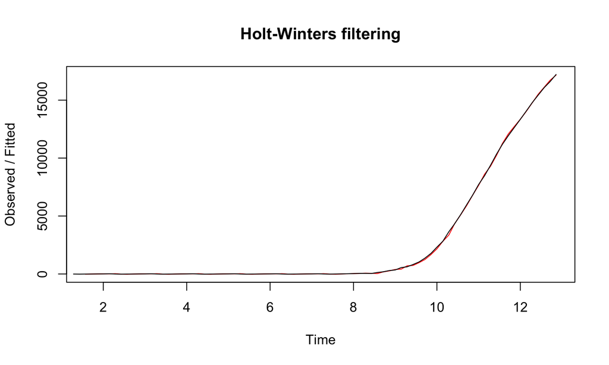

```r
plot(predicción.fallecidos)
```

## Predicciones usando el suavizado exponencial

```r
(predicción.fallecidos.semana = forecast:::forecast.HoltWinters(predicción.fallecidos,
                                                                h=7))
```

```
##          Point Forecast    Lo 80    Hi 80    Lo 95    Hi 95
## 13.00000       17787.53 17710.92 17864.14 17670.36 17904.69
## 13.14286       18370.40 18222.39 18518.41 18144.04 18596.76
## 13.28571       18953.27 18712.46 19194.09 18584.98 19321.57
## 13.42857       19536.15 19186.66 19885.64 19001.65 20070.64
## 13.57143       20119.02 19647.45 20590.59 19397.81 20840.22
## 13.71429       20701.89 20096.32 21307.47 19775.75 21628.04
## 13.85714       21284.77 20534.31 22035.22 20137.05 22432.49
```

## Predicciones usando el suavizado exponencial

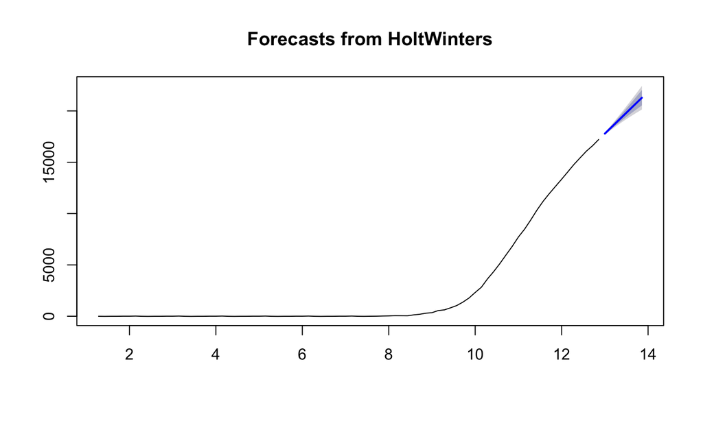

```r
forecast:::plot.forecast(predicción.fallecidos.semana)
```

## Comprobación del modelo

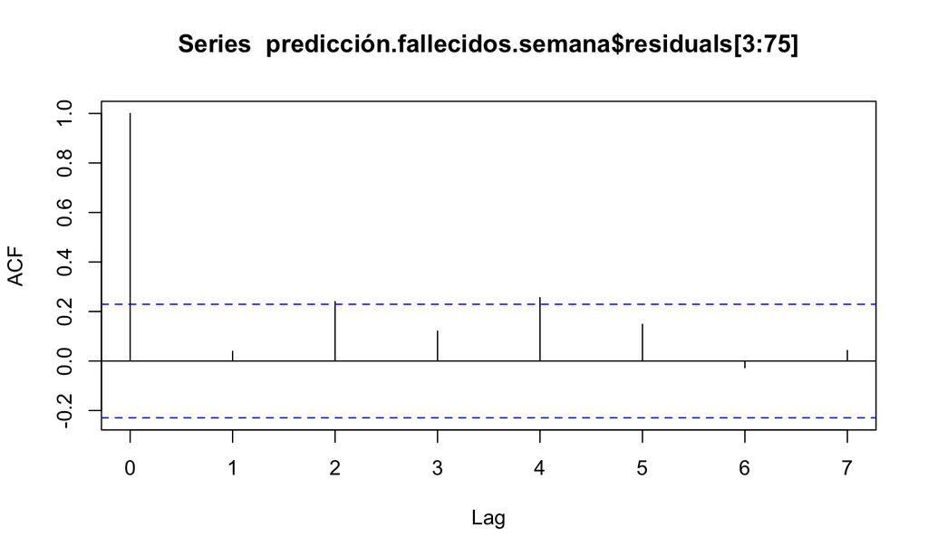

```r
acf(predicción.fallecidos.semana$residuals[3:75], lag.max=7)
```

## Comprobación del modelo

```r
Box.test(predicción.fallecidos.semana$residuals,lag=7,type="Ljung-Box")
```

```
##
##  Box-Ljung test
##
## data:  predicción.fallecidos.semana$residuals
## X-squared = 15.975, df = 7, p-value = 0.02534
```

## Comprobación del modelo

```r
shapiro.test(predicción.fallecidos.semana$residuals)
```

```
##
##  Shapiro-Wilk normality test
##
## data:  predicción.fallecidos.semana$residuals
## W = 0.86012, p-value = 3.596e-07
```